# Final Project - Heart Failure Analysis

David Olander

2022-12-16

# Introduction:

Heart failure is a syndrome that is a result of functional or structural impairment of ventricles which can result in insufficient cardiac output, and the heart fails to keep up with the needs of the body.^1 Cardiovascular diseases, or CVDs, is an umbrella term to describe all the diseases of the heart or of the blood vessels; this includes heart disease, heart attack, stroke, arrhythmia, and other heart or blood vessel conditions.^2 It is estimated that approximately 17.9 million lives are lost yearly due to CVDs worldwide.^3 This ranks as the number one leading cause of death worldwide, higher than cancer. Heart failure is usually an event caused by CVDs, and to explore this topic, I chose a dataset to look at the association between certain variables and the outcome of death from heart failure.

To explore this topic and conduct an analysis, I obtained a dataset from Kaggle that included data on clinical data about heart failure. The dataset is pre-processed and includes data for 299 patients with heart failure in 2015. The variables that are included in this dataset are age, anemia status, creatinine phosphokinase levels, diabetes status, ejection fraction, high blood pressure status, platelet counts (kiloplatelets/mL), serum creatinine levels in blood (mg/dL), serum sodium levels in blood (mEq/L), sex, smoking status, and death event.

For my analysis, I have decided to answer the question of: what variables are associated with death from heart failure, how can we model this, and what is a sufficient prediction model to possibly predict the outcome of death?

For my analysis, I will assess the association between ejection fraction, serum sodium, and serum creatinine on the outcome, death from heart failure, and while controlling for age. Because the outcome of death from heart failure is binary, where death = 1 and no death = 0, I decided to measure the association by fitting a logistic regression model and obtain an odds ratio. The reason why I was interested in these variables are a result of my exploratory data analysis and getting to know my data better, where I determined that these covariates would be important to include in my model. Additionally, I will create a couple prediction models from the data to assess the logistic regression covariates I included to including all the covariates.

## Exploratory Analysis:

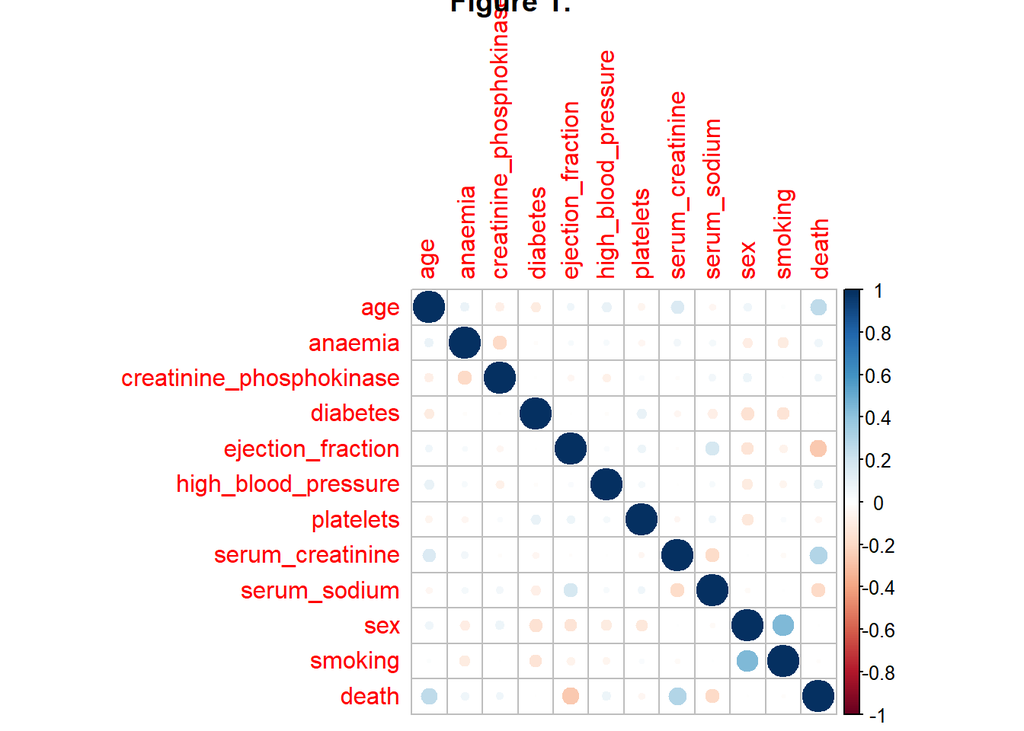

[figure not shown]

### Figure 2,3,4,5: Here are 4 plots of the varaible distributions that I found to be the most interesting and important. I looked at the distributions of each variable and grouped by death outcome to see if there was anything I could see different from the 2 group (death and no death). Note: more EDA can be found in the appendix

# Results (Route 2):

## Logistic Regression and Association:

To begin with association tests and logistic regression, I began fitting various models. I first checked and verified assumptions for fitting a logistic regression model, and proceeded. For my first model, I began simple and had just age to predict the death outcome. Age was a statistically significant variable for this model, and following *(Table 1)*, it had an AIC value of 359.993. An AIC value, or Akaike Information Criteria, helps assess a model fit in relation to other models, hence why I decided to assess my models this way. A lower AIC value relative to its other models means a better fit. Next, I fit a model, model2, with age and ejection fraction, and found that both covariates were also statisitcally significant, with and the model having an AIC value of 333.4015, suggesting improvement to our model. Continuing, I fit another model, model3, adding serum sodium level to the model, and found it was also statistically significant, with an AIC value of 329.95. This continues to show that the model is imporving fit. Furthermore, I continued this with model4, adding on serum creatinine, and then finally model5, which included an interaction term of age to help assess effect modification since age is a confounder.

For our findings given the model selection of model4, our data shows that those with one-unit higher in age have a 1.05 times the odds of death associated with heart failure occurring compared to those with one-unit lower, on average, holding all other covariates constant, with a 95% CI: [1.028, 1.079]. This suggests that with age, the odds of death is greater. Additionally, those with a one-unit higher in ejection fraction have a 0.935 times the odds of death associated with heart failure occurring compared to those with one-unit lower, on average, holding all other covariates constant, with a 95% CI: [0.908, 0.961]. This suggests that higher ejection fractions have a protective effect on heart failure. Those with one-unit higher in serum sodium levels have a 0.953 times the odds of death associated with heart failure occurring compared to those with one-unit lower, on average, holding all other covariates constant. However, the 95% CI [0.894, 1.016] includes 1, suggesting that this may not significant. Finally, those with one-unit higher in serum creatinine levels have a 1.88 times the odds of death associated with heart failure occurring compared to those with one-unit lower, on average, holding all other covariates constant, with a 95% CI: [1.406, 2.655].

## Prediction Model:

# Conclusion:

The purpose of my analysis was to assess the association between ejection fraction, serum sodium, and serum creatinine on the outcome, death from heart failure, and while controlling for age, and model this. Also, to create a prediction model from the data to assess the logistic regression covariates I included versus including all the covariates.

I would say that my analysis was successful with fitting a regression model and doing an association test, as well as doing a prediction model. However, I would say that the time constraint hindered my analysis as I chose a fairly small data set that may not be representative of the US population or really any population. Therefore, if I had more time, I would chose a different dataset that included many more observations. I would also like to explore applying kNN or random forest to the bigger dataset and comparing it to the approach of using logistic regression. In other words, I would like to see if the logistic regression would be just as close or even better than the models.

### TABLE 1: Shows the AIC values for various fitted logistic regression models

```
##     TABLE_1  model_1  model_2  model_3  model_4  model_5
## 1 AIC VALUE 359.9928 333.4015 329.9527 313.0898 315.5374
```

### TABLE 2: Logistic Regression Model fit with age, ejection fraction, serum sodium, and serum creatining

```
##                           OR      2.5 %       97.5 %    Estimate Std. Error
## (Intercept)       59.9748292 0.01004444 4.353118e+05  4.09392496 4.45542181
## age                1.0527795 1.02812862 1.079299e+00  0.05143385 0.01234615
## ejection_fraction  0.9356515 0.90872881 9.612421e-01 -0.06651218 0.01428788
## serum_sodium       0.9534492 0.89372396 1.015543e+00 -0.04766916 0.03238247
## serum_creatinine   1.8808690 1.40580940 2.655471e+00  0.63173389 0.15843305
##                      z value     Pr(>|z|)
## (Intercept)        0.9188636 3.581669e-01
## age                4.1659835 3.100131e-05
## ejection_fraction -4.6551457 3.237517e-06
## serum_sodium      -1.4720668 1.410028e-01
## serum_creatinine   3.9873869 6.680503e-05
```

### TABLE 3: Likelihood Ratio Test to assess model covariates

```
## Analysis of Deviance Table
##
## Model 1: death ~ age + ejection_fraction + serum_sodium
## Model 2: death ~ age + ejection_fraction + serum_sodium + serum_creatinine
##   Resid. Df Resid. Dev Df Deviance  Pr(>Chi)
## 1       295     321.95
## 2       294     303.09  1   18.863 1.405e-05 ***
## ---
## Signif. codes:  0 '***' 0.001 '**' 0.01 '*' 0.05 '.' 0.1 ' ' 1
```

### TABLE 4: Likelihood Ratio Test to assess model covariates

```
## Analysis of Deviance Table
##
## Model 1: death ~ age + ejection_fraction + serum_sodium + serum_creatinine
## Model 2: death ~ age + ejection_fraction + age * ejection_fraction + age *
##     serum_sodium + age * serum_creatinine
##   Resid. Df Resid. Dev Df Deviance Pr(>Chi)
## 1       294     303.09
## 2       291     299.54  3   3.5523    0.314
```

### TABLE 5: Prediction Model4

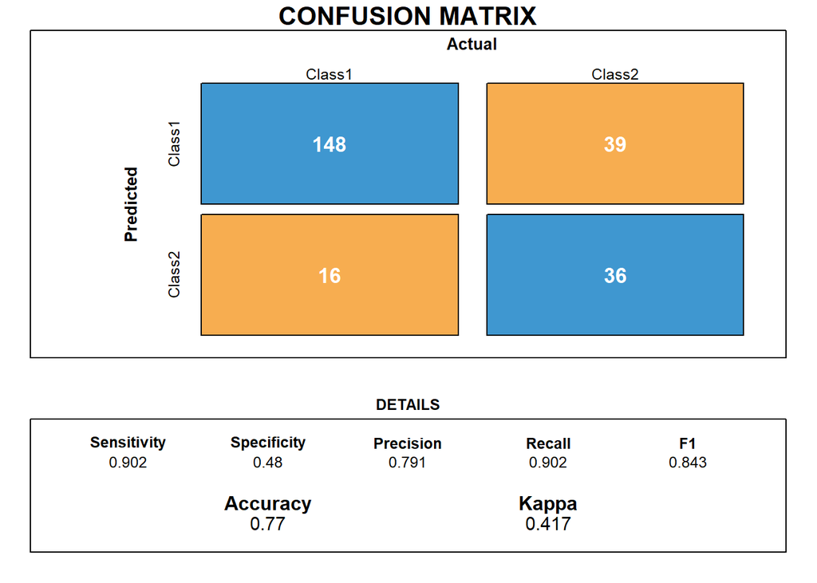

### TABLE 6: Prediction Model with all covariates

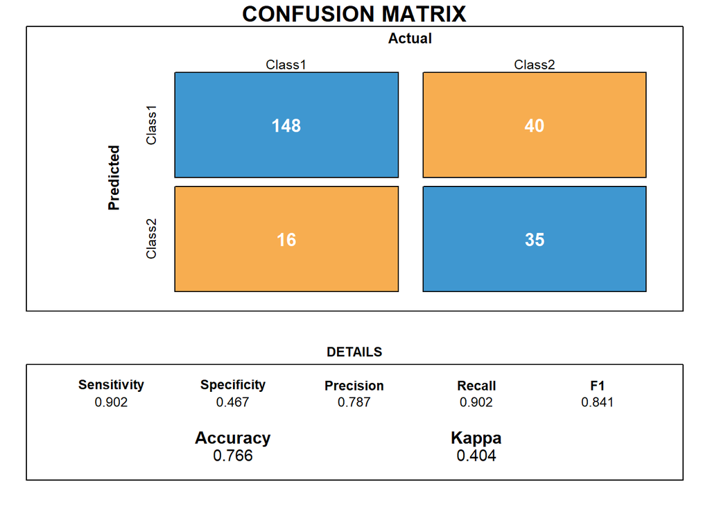

# References:

1. NHLBI. Know the Differences: Cardiovascular Disease, Heart Disease, Coronary Heart Disease. NHLBI - NIH. Know the Differences Cardiovascular Disease, Heart Disease, Coronary Heart Disease. Published 2019.
2. WHO. Cardiovascular diseases. World Health Organization. https://www.who.int/health-topics/cardiovascular-diseases/#tab=tab_1. Published 2020.
3. Gaziano TA, Bitton A, Anand S, Abrahams-Gessel S, Murphy A. Growing epidemic of coronary heart disease in low- and middle-income countries. Curr Probl Cardiol. 2010;35(2):72-115. doi:10.1016/j.cpcardiol.2009.10.002
4. https://stackoverflow.com/questions/23891140/r-how-to-visualize-confusion-matrix-using-the-caret-package

# Appendix:

```r
knitr::opts_chunk$set(echo = TRUE)

library(dplyr)
library(ggplot2)
library(corrplot)
library(glmnet)
library(HistData)
library(caret)
library(randomForest)
library(gridExtra)

#Function to draw confusion matrix [source 4]:
draw_confusion_matrix <- function(cm) {

  layout(matrix(c(1,1,2)))
  par(mar=c(2,2,2,2))
  plot(c(100, 345), c(300, 450), type = "n", xlab="", ylab="", xaxt='n', yaxt='n')
  title('CONFUSION MATRIX', cex.main=2)

  # create the matrix
  rect(150, 430, 240, 370, col='#3F97D0')
  text(195, 435, 'Class1', cex=1.2)
  rect(250, 430, 340, 370, col='#F7AD50')
  text(295, 435, 'Class2', cex=1.2)
  text(125, 370, 'Predicted', cex=1.3, srt=90, font=2)
  text(245, 450, 'Actual', cex=1.3, font=2)
  rect(150, 305, 240, 365, col='#F7AD50')
  rect(250, 305, 340, 365, col='#3F97D0')
  text(140, 400, 'Class1', cex=1.2, srt=90)
  text(140, 335, 'Class2', cex=1.2, srt=90)

  # add in the cm results
  res <- as.numeric(cm$table)
  text(195, 400, res[1], cex=1.6, font=2, col='white')
  text(195, 335, res[2], cex=1.6, font=2, col='white')
  text(295, 400, res[3], cex=1.6, font=2, col='white')
  text(295, 335, res[4], cex=1.6, font=2, col='white')

  # add in the specifics
  plot(c(100, 0), c(100, 0), type = "n", xlab="", ylab="", main = "DETAILS", xaxt='n', yaxt='n')
  text(10, 85, names(cm$byClass[1]), cex=1.2, font=2)
  text(10, 70, round(as.numeric(cm$byClass[1]), 3), cex=1.2)
  text(30, 85, names(cm$byClass[2]), cex=1.2, font=2)
  text(30, 70, round(as.numeric(cm$byClass[2]), 3), cex=1.2)
  text(50, 85, names(cm$byClass[5]), cex=1.2, font=2)
  text(50, 70, round(as.numeric(cm$byClass[5]), 3), cex=1.2)
  text(70, 85, names(cm$byClass[6]), cex=1.2, font=2)
  text(70, 70, round(as.numeric(cm$byClass[6]), 3), cex=1.2)
  text(90, 85, names(cm$byClass[7]), cex=1.2, font=2)
  text(90, 70, round(as.numeric(cm$byClass[7]), 3), cex=1.2)

  # add in the accuracy information
  text(30, 35, names(cm$overall[1]), cex=1.5, font=2)
  text(30, 20, round(as.numeric(cm$overall[1]), 3), cex=1.4)
  text(70, 35, names(cm$overall[2]), cex=1.5, font=2)
  text(70, 20, round(as.numeric(cm$overall[2]), 3), cex=1.4)
}
```

```r
## Loading in data:
heart_failure <- read.csv("heart_failure.csv")
```

```r
# Exploratory Data Analysis:

## Look at Data Structure:
heart_failure %>% head()
```

```
##   age anaemia creatinine_phosphokinase diabetes ejection_fraction
## 1  75       0                      582        0                20
## 2  55       0                     7861        0                38
## 3  65       0                      146        0                20
## 4  50       1                      111        0                20
## 5  65       1                      160        1                20
## 6  90       1                       47        0                40
##   high_blood_pressure platelets serum_creatinine serum_sodium sex smoking time
## 1                   1    265000              1.9          130   1       0    4
## 2                   0    263358              1.1          136   1       0    6
## 3                   0    162000              1.3          129   1       1    7
## 4                   0    210000              1.9          137   1       0    7
## 5                   0    327000              2.7          116   0       0    8
## 6                   1    204000              2.1          132   1       1    8
##   DEATH_EVENT
## 1           1
## 2           1
## 3           1
## 4           1
## 5           1
## 6           1
```

```r
str(heart_failure)
```

```
## 'data.frame':    299 obs. of  13 variables:
##  $ age                     : num  75 55 65 50 65 90 75 60 65 80 ...
##  $ anaemia                 : int  0 0 0 1 1 1 1 1 0 1 ...
##  $ creatinine_phosphokinase: int  582 7861 146 111 160 47 246 315 157 123 ...
##  $ diabetes                : int  0 0 0 0 1 0 0 1 0 0 ...
##  $ ejection_fraction       : int  20 38 20 20 20 40 15 60 65 35 ...
##  $ high_blood_pressure     : int  1 0 0 0 0 1 0 0 0 1 ...
##  $ platelets               : num  265000 263358 162000 210000 327000 ...
##  $ serum_creatinine        : num  1.9 1.1 1.3 1.9 2.7 2.1 1.2 1.1 1.5 9.4 ...
##  $ serum_sodium            : int  130 136 129 137 116 132 137 131 138 133 ...
##  $ sex                     : int  1 1 1 1 0 1 1 1 0 1 ...
##  $ smoking                 : int  0 0 1 0 0 1 0 1 0 1 ...
##  $ time                    : int  4 6 7 7 8 8 10 10 10 10 ...
##  $ DEATH_EVENT             : int  1 1 1 1 1 1 1 1 1 1 ...
```

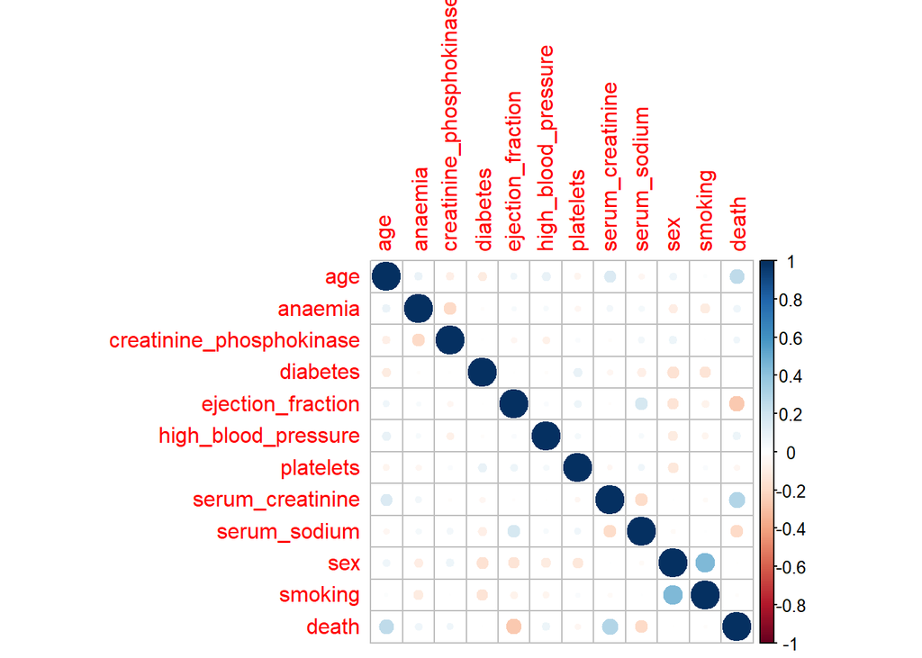

```r
## Renaming Variable(s):
heart_failure <- heart_failure %>%
  rename(death = DEATH_EVENT)

heart_failure <- subset(heart_failure, select = -c(time))

corr <- cor(heart_failure)
corrplot(corr)
```

```r
## Number of Variables:
length(heart_failure)
```

```
## [1] 12
```

```r
## Number of Rows:
nrow(heart_failure)
```

```
## [1] 299
```

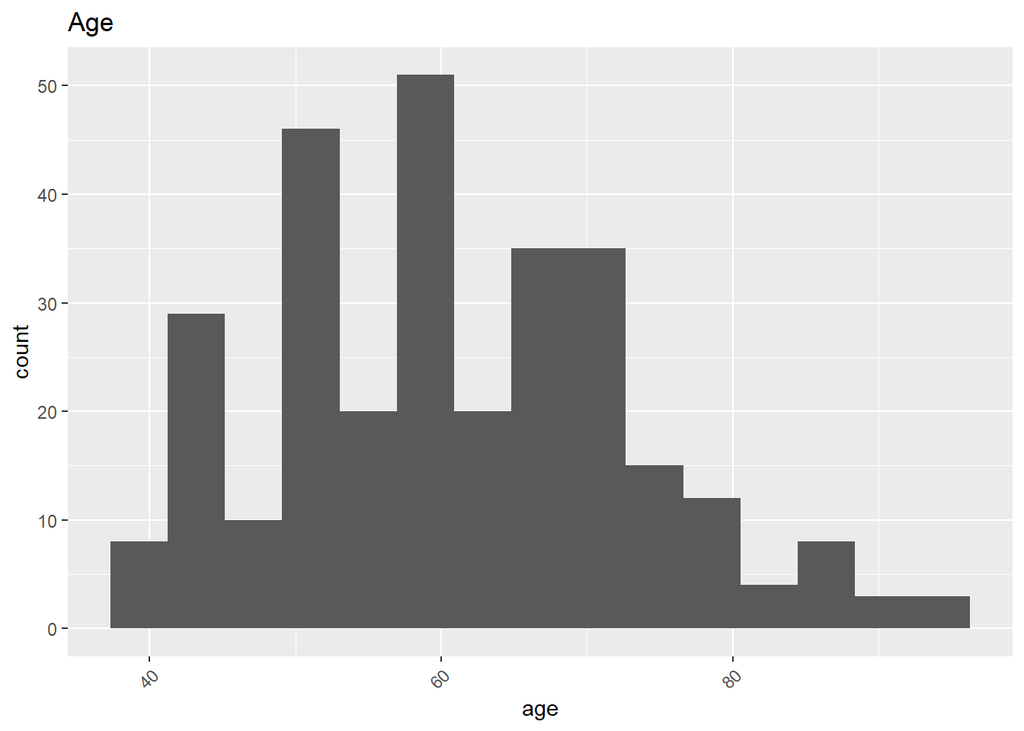

```r
## Distribution of Certain Variables:
### Age
heart_failure %>%
  ggplot(aes(x = age)) + geom_histogram(bins = 15) + theme(axis.text.x = element_text(angle = 45, hjust = 1)) + ggtitle("Age")
```

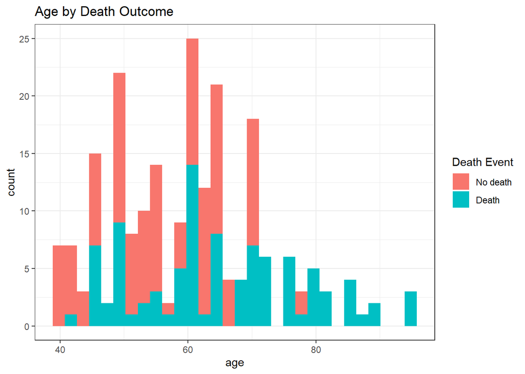

```r
heart_failure %>%
  ggplot(aes(x = age, group = factor(death), fill = factor(death))) +
  geom_histogram(position = "identity") +
  scale_fill_discrete(name = "Death Event", labels = c("No death", "Death")) +
  labs(title = "Age by Death Outcome", color = "Death Event") +
  theme_bw()
```

```r
summary(heart_failure$age)
```

```
##    Min. 1st Qu.  Median    Mean 3rd Qu.    Max.
##   40.00   51.00   60.00   60.83   70.00   95.00
```

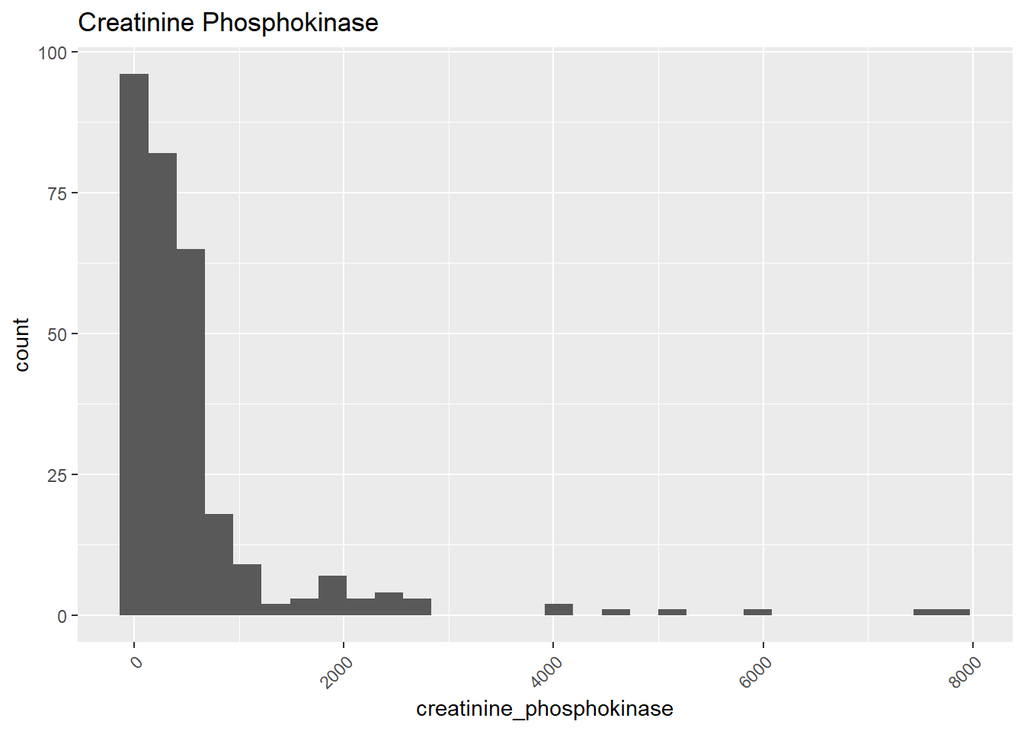

```r
### Creatinine Phosphokinase
heart_failure %>%
  ggplot(aes(x = creatinine_phosphokinase)) + geom_histogram() + theme(axis.text.x = element_text(angle = 45, hjust = 1)) +
  ggtitle("Creatinine Phosphokinase")
```

```r
summary(heart_failure$creatinine_phosphokinase)
```

```
##    Min. 1st Qu.  Median    Mean 3rd Qu.    Max.
##    23.0   116.5   250.0   581.8   582.0  7861.0
```

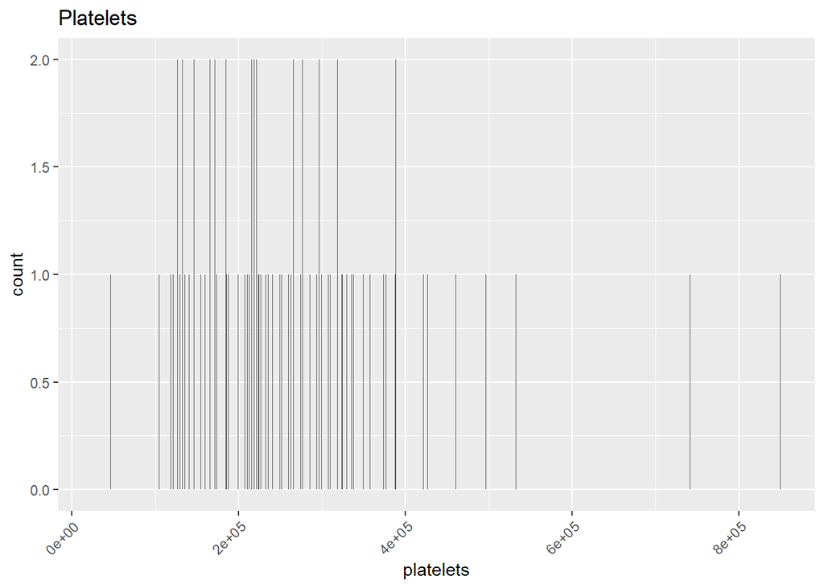

```r
### Platelets
heart_failure %>%
  ggplot(aes(x = platelets)) + geom_bar() + ylim(0,2) + theme(axis.text.x = element_text(angle = 45, hjust = 1)) +
  ggtitle("Platelets")
```

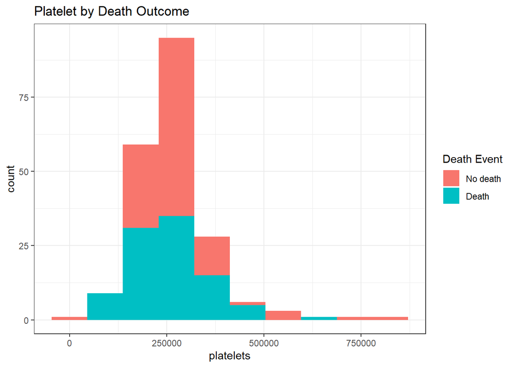

```r
heart_failure %>%
  ggplot(aes(x = platelets, group = factor(death), fill = factor(death))) +
  geom_histogram(position = "identity", bins = 10) +
  scale_fill_discrete(name = "Death Event", labels = c("No death", "Death")) +
  labs(title = "Platelet by Death Outcome", color = "Death Event") +
  theme_bw()
```

```r
summary(heart_failure$platelets)
```

```
##    Min. 1st Qu.  Median    Mean 3rd Qu.    Max.
##   25100  212500  262000  263358  303500  850000
```

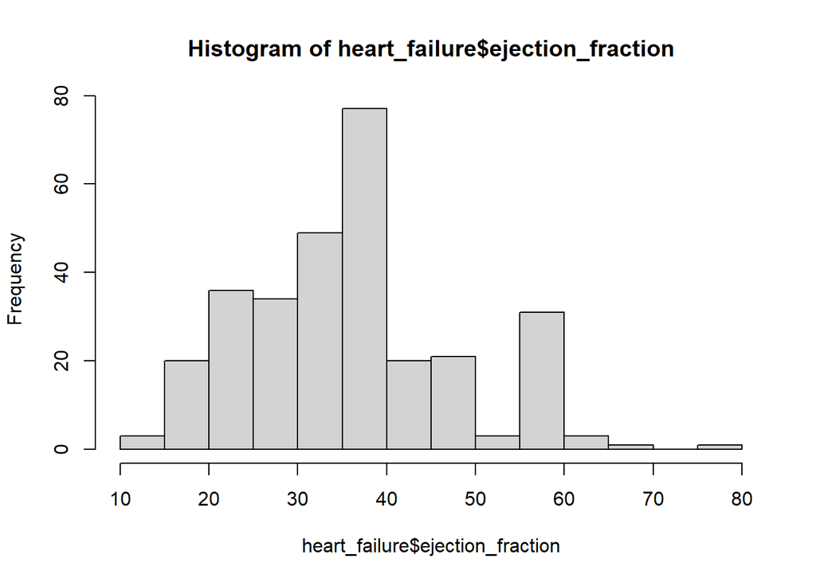

```r
## Ejection Fraction
hist(heart_failure$ejection_fraction)
```

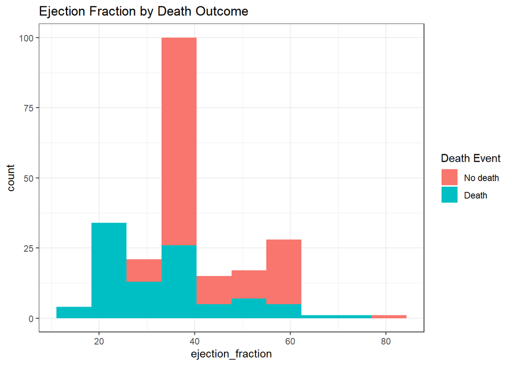

```r
heart_failure %>%
  ggplot(aes(x = ejection_fraction, group = factor(death), fill = factor(death))) +
  geom_histogram(position = "identity", bins = 10) +
  scale_fill_discrete(name = "Death Event", labels = c("No death", "Death")) +
  labs(title = "Ejection Fraction by Death Outcome", color = "Death Event") +
  theme_bw()
```

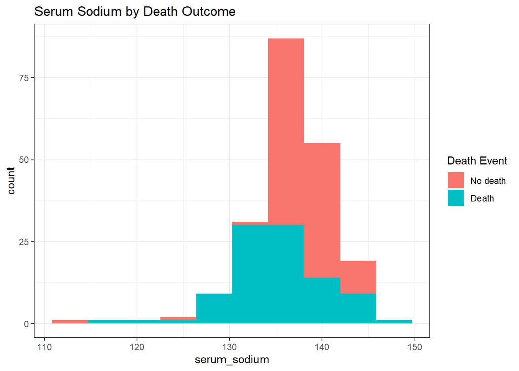

```r
## Serum Sodium:
heart_failure %>%
  ggplot(aes(x = serum_sodium, group = factor(death), fill = factor(death))) +
  geom_histogram(position = "identity", bins = 10) +
  scale_fill_discrete(name = "Death Event", labels = c("No death", "Death")) +
  labs(title = "Serum Sodium by Death Outcome", color = "Death Event") +
  theme_bw()
```

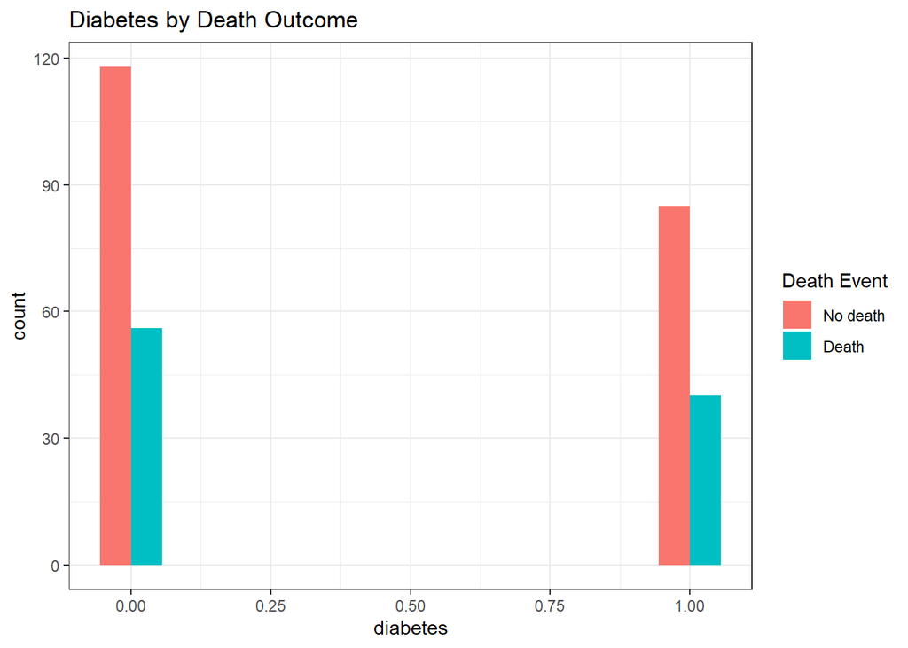

```r
## Diabetes:
heart_failure %>%
  ggplot(aes(x = diabetes, group = factor(death), fill = factor(death))) +
  geom_histogram(position = "dodge", bins = 10) +
  scale_fill_discrete(name = "Death Event", labels = c("No death", "Death")) +
  labs(title = "Diabetes by Death Outcome", color = "Death Event") +
  theme_bw()
```

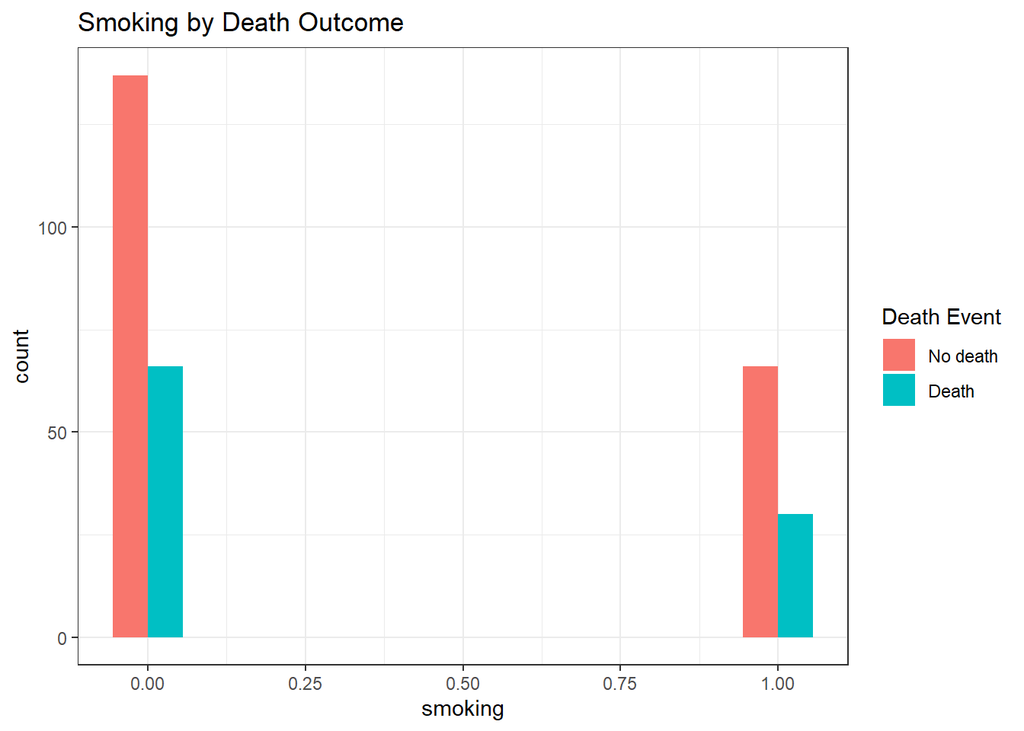

```r
## Smoking:
heart_failure %>%
  ggplot(aes(x = smoking, group = factor(death), fill = factor(death))) +
  geom_histogram(position = "dodge", bins = 10) +
  scale_fill_discrete(name = "Death Event", labels = c("No death", "Death")) +
  labs(title = "Smoking by Death Outcome", color = "Death Event") +
  theme_bw()
```

```r
## Checking Missing Data:
sum(is.na(heart_failure))
```

```
## [1] 0
```

```r
## Count of Death Events:
sum(heart_failure$death)
```

```
## [1] 96
```

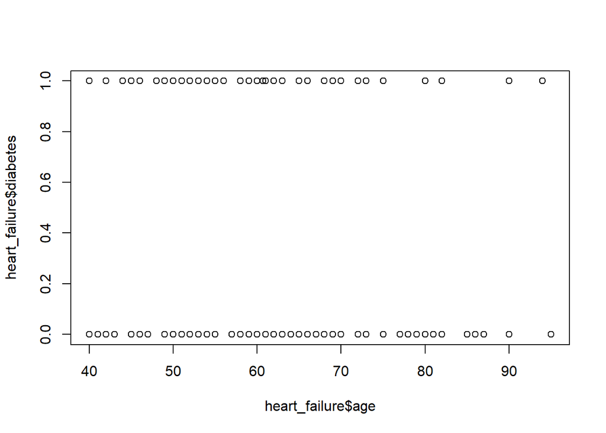

```r
# Graphs:
plot(heart_failure$age, heart_failure$diabetes)
```

# Logistic Regression, Model Selection, Association:

```r
death_factor <- as.factor(heart_failure$death)

# With Just Age as Covariate:
model1 <- glm(death ~ age, data = heart_failure, family = "binomial")
logOR.scale <- summary(model1)$coefficients
OR.scale <- exp(cbind(OR = coef(model1), confint(model1)))
cbind(OR.scale, logOR.scale)
```

```
##                     OR      2.5 %     97.5 %    Estimate Std. Error   z value
## (Intercept) 0.02587886 0.00620156 0.09979039 -3.65432880 0.70661721 -5.171582
## age         1.04806947 1.02602488 1.07168816  0.04694987 0.01107111  4.240755
##                 Pr(>|z|)
## (Intercept) 2.321205e-07
## age         2.227688e-05
```

```r
model1$aic
```

```
## [1] 359.9928
```

```r
# Age and Ejection Fraction:
model2 <- glm(death ~ age + ejection_fraction, data = heart_failure, family = "binomial")
logOR.scale <- summary(model2)$coefficients
OR.scale <- exp(cbind(OR = coef(model2), confint(model2)))
cbind(OR.scale, logOR.scale)
```

```
##                          OR      2.5 %    97.5 %    Estimate Std. Error
## (Intercept)       0.1661441 0.03381588 0.7859550 -1.79489972 0.79987731
## age               1.0574074 1.03374437 1.0830121  0.05582006 0.01183810
## ejection_fraction 0.9362606 0.91069761 0.9604511 -0.06586146 0.01353153
##                     z value     Pr(>|z|)
## (Intercept)       -2.243969 2.483441e-02
## age                4.715287 2.413699e-06
## ejection_fraction -4.867258 1.131573e-06
```

```r
model2$aic
```

```
## [1] 333.4015
```

```r
# Age, EF, and Sodium:
model3 <- glm(death ~ age + ejection_fraction + serum_sodium, data = heart_failure, family = "binomial")
logOR.scale <- summary(model3)$coefficients
OR.scale <- exp(cbind(OR = coef(model3), confint(model3)))
cbind(OR.scale, logOR.scale)
```

```
##                             OR     2.5 %       97.5 %    Estimate Std. Error
## (Intercept)       2917.5327680 0.6777970 1.792618e+07  7.97849360 4.33689957
## age                  1.0561640 1.0323735 1.081873e+00  0.05464347 0.01190790
## ejection_fraction    0.9407637 0.9149182 9.652999e-01 -0.06106324 0.01363379
## serum_sodium         0.9301466 0.8728174 9.885517e-01 -0.07241306 0.03160279
##                     z value     Pr(>|z|)
## (Intercept)        1.839677 6.581570e-02
## age                4.588841 4.457137e-06
## ejection_fraction -4.478815 7.505841e-06
## serum_sodium      -2.291351 2.194315e-02
```

```r
model3$aic
```

```
## [1] 329.9527
```

```r
#Age, EF, and serum_sodium, serum_creatinine:
model4 <- glm(death ~ age + ejection_fraction + serum_sodium + serum_creatinine, data = heart_failure, family = "binomial")
logOR.scale <- summary(model4)$coefficients
OR.scale <- exp(cbind(OR = coef(model4), confint(model4)))
cbind(OR.scale, logOR.scale)
```

```
##                           OR      2.5 %       97.5 %    Estimate Std. Error
## (Intercept)       59.9748292 0.01004444 4.353118e+05  4.09392496 4.45542181
## age                1.0527795 1.02812862 1.079299e+00  0.05143385 0.01234615
## ejection_fraction  0.9356515 0.90872881 9.612421e-01 -0.06651218 0.01428788
## serum_sodium       0.9534492 0.89372396 1.015543e+00 -0.04766916 0.03238247
## serum_creatinine   1.8808690 1.40580940 2.655471e+00  0.63173389 0.15843305
##                      z value     Pr(>|z|)
## (Intercept)        0.9188636 3.581669e-01
## age                4.1659835 3.100131e-05
## ejection_fraction -4.6551457 3.237517e-06
## serum_sodium      -1.4720668 1.410028e-01
## serum_creatinine   3.9873869 6.680503e-05
```

```r
model4$aic
```

```
## [1] 313.0898
```

```r
# Interaction Term:
model5 <- glm(death ~ age + ejection_fraction + age*ejection_fraction+ age*serum_sodium + age*serum_creatinine, data = heart_failure, family = "binomial")


# LRT to see if reduced or full model preferred:
anova(model3, model4, test = "Chisq")
```

```
## Analysis of Deviance Table
##
## Model 1: death ~ age + ejection_fraction + serum_sodium
## Model 2: death ~ age + ejection_fraction + serum_sodium + serum_creatinine
##   Resid. Df Resid. Dev Df Deviance  Pr(>Chi)
## 1       295     321.95
## 2       294     303.09  1   18.863 1.405e-05 ***
## ---
## Signif. codes:  0 '***' 0.001 '**' 0.01 '*' 0.05 '.' 0.1 ' ' 1
```

```r
# LRT to see if interaction terms needed:
anova(model4, model5, test = "Chisq")
```

```
## Analysis of Deviance Table
##
## Model 1: death ~ age + ejection_fraction + serum_sodium + serum_creatinine
## Model 2: death ~ age + ejection_fraction + age * ejection_fraction + age *
##     serum_sodium + age * serum_creatinine
##   Resid. Df Resid. Dev Df Deviance Pr(>Chi)
## 1       294     303.09
## 2       291     299.54  3   3.5523    0.314
```

# Prediction:

```r
set.seed(1)
dt = sort(sample(nrow(heart_failure), nrow(heart_failure)*.8))
train <- heart_failure[dt,]
test <- heart_failure[-dt,]

training_model <- glm(death ~ ., data = train, family = "binomial")

results <- train %>%
  mutate(pred_prob_model = predict(training_model, newdata = train, type = "response")) %>%
  mutate(pred_outcome_model = ifelse(pred_prob_model >= 0.5, 1,0))

results$death <- as.factor(results$death)
results$pred_outcome_model <- as.factor(results$pred_outcome_model)

confusionMatrix(results$pred_outcome_model, results$death)
```

```
## Confusion Matrix and Statistics
##
##           Reference
## Prediction   0   1
##          0 148  40
##          1  16  35
##
##                Accuracy : 0.7657
##                  95% CI : (0.7068, 0.8179)
##     No Information Rate : 0.6862
##     P-Value [Acc > NIR] : 0.004183
##
##                   Kappa : 0.4042
##
##  Mcnemar's Test P-Value : 0.002116
##
##             Sensitivity : 0.9024
##             Specificity : 0.4667
##          Pos Pred Value : 0.7872
##          Neg Pred Value : 0.6863
##              Prevalence : 0.6862
##          Detection Rate : 0.6192
##    Detection Prevalence : 0.7866
##       Balanced Accuracy : 0.6846
##
##        'Positive' Class : 0
##
```

```r
training_model <- glm(death ~ age + ejection_fraction + serum_sodium + serum_creatinine, data = heart_failure, family = "binomial")

results <- train %>%
  mutate(pred_prob_model = predict(training_model, newdata = train, type = "response")) %>%
  mutate(pred_outcome_model = ifelse(pred_prob_model >= 0.5, 1,0))

results$death <- as.factor(results$death)
results$pred_outcome_model <- as.factor(results$pred_outcome_model)


confusionMatrix(results$pred_outcome_model, results$death)
```

```
## Confusion Matrix and Statistics
##
##           Reference
## Prediction   0   1
##          0 148  39
##          1  16  36
##
##                Accuracy : 0.7699
##                  95% CI : (0.7112, 0.8217)
##     No Information Rate : 0.6862
##     P-Value [Acc > NIR] : 0.002680
##
##                   Kappa : 0.4172
##
##  Mcnemar's Test P-Value : 0.003012
##
##             Sensitivity : 0.9024
##             Specificity : 0.4800
##          Pos Pred Value : 0.7914
##          Neg Pred Value : 0.6923
##              Prevalence : 0.6862
##          Detection Rate : 0.6192
##    Detection Prevalence : 0.7824
##       Balanced Accuracy : 0.6912
##
##        'Positive' Class : 0
##
```